# Chapter 5

Paloma

2019-12-27

# Data transformation

## Intro

Some key concepts

**Different types of variables**

- `int` as integers
- `dbl` stands for doubles, real numbers
- `chr` stands for character vectors, or strings
- `dttm` stands for date-times (a date + a time)
- `lgl` logical, TRUE or FALSE
- `fctr` factors, categorical variables with fixed possible values
- `date` stands for dates

About `dplyr` verbs:

1. First argument is a data frame
2. The subsequent argument describe what to do with the data frame, using the variable names (*without quotes*).
3. The result is a new data frame

## 5.2 Filter rows with `filter`

**Def**: *subset observations based on their values.*

**Logical operators**

`x`

```r
table2 %>%
  filter(country == "Brazil") %>%
  mytable()
```

| country | year | type | count |
| --- | --- | --- | --- |
| Brazil | 1999 | cases | 37737 |
| Brazil | 1999 | population | 172006362 |
| Brazil | 2000 | cases | 80488 |
| Brazil | 2000 | population | 174504898 |

`y`

```r
table2 %>%
  filter(type == "cases") %>%
  mytable()
```

| country | year | type | count |
| --- | --- | --- | --- |
| Afghanistan | 1999 | cases | 745 |
| Afghanistan | 2000 | cases | 2666 |
| Brazil | 1999 | cases | 37737 |
| Brazil | 2000 | cases | 80488 |
| China | 1999 | cases | 212258 |
| China | 2000 | cases | 213766 |

`x & y`

```r
table2 %>%
  filter(type == "cases" & country == "Brazil") %>%
  mytable()
```

| country | year | type | count |
| --- | --- | --- | --- |
| Brazil | 1999 | cases | 37737 |
| Brazil | 2000 | cases | 80488 |

`x | y`

```r
table2 %>%
  filter(type == "cases" | country == "Brazil") %>%
  mytable()
```

| country | year | type | count |
| --- | --- | --- | --- |
| Afghanistan | 1999 | cases | 745 |
| Afghanistan | 2000 | cases | 2666 |
| Brazil | 1999 | cases | 37737 |
| Brazil | 1999 | population | 172006362 |
| Brazil | 2000 | cases | 80488 |
| Brazil | 2000 | population | 174504898 |
| China | 1999 | cases | 212258 |
| China | 2000 | cases | 213766 |

`y & !x`

```r
table2 %>%
  filter(type == "cases" & country != "Brazil") %>%
  mytable()
```

| country | year | type | count |
| --- | --- | --- | --- |
| Afghanistan | 1999 | cases | 745 |
| Afghanistan | 2000 | cases | 2666 |
| China | 1999 | cases | 212258 |
| China | 2000 | cases | 213766 |

`x & !y`

```r
table2 %>%
  filter(country == "Brazil" & type != "cases") %>%
  mytable()
```

| country | year | type | count |
| --- | --- | --- | --- |
| Brazil | 1999 | population | 172006362 |
| Brazil | 2000 | population | 174504898 |

`xor(x,y)`

```r
table2 %>%
  filter(xor(country == "Brazil",
             type == "cases")) %>%
  mytable()
```

| country | year | type | count |
| --- | --- | --- | --- |
| Afghanistan | 1999 | cases | 745 |
| Afghanistan | 2000 | cases | 2666 |
| Brazil | 1999 | population | 172006362 |
| Brazil | 2000 | population | 174504898 |
| China | 1999 | cases | 212258 |
| China | 2000 | cases | 213766 |

`%in%`

```r
table2 %>%
  filter(country %in% c("Brazil", "China")) %>%
  mytable()
```

| country | year | type | count |
| --- | --- | --- | --- |
| Brazil | 1999 | cases | 37737 |
| Brazil | 1999 | population | 172006362 |
| Brazil | 2000 | cases | 80488 |
| Brazil | 2000 | population | 174504898 |
| China | 1999 | cases | 212258 |
| China | 1999 | population | 1272915272 |
| China | 2000 | cases | 213766 |
| China | 2000 | population | 1280428583 |

`!(x&y) = !x|!y`

```r
table2 %>%
  filter(!(country == "Brazil" & type == "cases"))%>%
  mytable()
```

| country | year | type | count |
| --- | --- | --- | --- |
| Afghanistan | 1999 | cases | 745 |
| Afghanistan | 1999 | population | 19987071 |
| Afghanistan | 2000 | cases | 2666 |
| Afghanistan | 2000 | population | 20595360 |
| Brazil | 1999 | population | 172006362 |
| Brazil | 2000 | population | 174504898 |
| China | 1999 | cases | 212258 |
| China | 1999 | population | 1272915272 |
| China | 2000 | cases | 213766 |
| China | 2000 | population | 1280428583 |

```r
table2 %>%
  filter(country != "Brazil" | type != "cases")%>%
  mytable()
```

| country | year | type | count |
| --- | --- | --- | --- |
| Afghanistan | 1999 | cases | 745 |
| Afghanistan | 1999 | population | 19987071 |
| Afghanistan | 2000 | cases | 2666 |
| Afghanistan | 2000 | population | 20595360 |
| Brazil | 1999 | population | 172006362 |
| Brazil | 2000 | population | 174504898 |
| China | 1999 | cases | 212258 |
| China | 1999 | population | 1272915272 |
| China | 2000 | cases | 213766 |
| China | 2000 | population | 1280428583 |

`!(x|y) = !x & !y`

```r
table2 %>%
  filter(!(country == "Brazil" | type == "cases"))%>%
  mytable()
```

| country | year | type | count |
| --- | --- | --- | --- |
| Afghanistan | 1999 | population | 19987071 |
| Afghanistan | 2000 | population | 20595360 |
| China | 1999 | population | 1272915272 |
| China | 2000 | population | 1280428583 |

```r
table2 %>%
  filter(country != "Brazil" & type != "cases")%>%
  mytable()
```

| country | year | type | count |
| --- | --- | --- | --- |
| Afghanistan | 1999 | population | 19987071 |
| Afghanistan | 2000 | population | 20595360 |
| China | 1999 | population | 1272915272 |
| China | 2000 | population | 1280428583 |

filter() only includes rows where the condition is TRUE; it excludes both FALSE and NA values. If you want to preserve missing values, ask for them explicitly:

```r
df <- tibble(x = c(1, NA, 3))

filter(df, x > 1)
```

```
## # A tibble: 1 x 1
##       x
##   <dbl>
## 1     3
```

```r
filter(df, is.na(x) | x > 1)
```

```
## # A tibble: 2 x 1
##       x
##   <dbl>
## 1    NA
## 2     3
```

1. Find all flights that

```r
library(nycflights13)
dim(flights)
```

```
## [1] 336776     19
```

1. Had an arrival delay of two or more hours

```r
 flights %>%
  filter(arr_delay >= 120) %>%
  count() %>%
  mytable()
```

| n |
| --- |
| 10200 |

2. Flew to Houston (IAH or HOU)

```r
flights %>%
  filter(dest %in% c("IAH", "HOU")) %>%
  count(dest) %>%
  mytable()
```

| dest | n |
| --- | --- |
| HOU | 2115 |
| IAH | 7198 |

3. Were operated by United, American, or Delta

```r
flights %>%
  filter(carrier %in% c("UA", "AA", "DL")) %>%
  count(carrier) %>%
  mytable()
```

| carrier | n |
| --- | --- |
| AA | 32729 |
| DL | 48110 |
| UA | 58665 |

4. Departed in summer (July, August, and September)

```r
flights %>%
  filter(between(month,7,9)) %>%
  count(month) %>%
  mytable()
```

| month | n |
| --- | --- |
| 7 | 29425 |
| 8 | 29327 |
| 9 | 27574 |

5. Arrived more than two hours late, but didn’t leave late

```r
flights %>%
  filter(dep_delay <= 0 & arr_delay > 120) %>%
  count() %>%
  mytable()
```

| n |
| --- |
| 29 |

6. Were delayed by at least an hour, but made up over 30 minutes in flight

```r
flights %>%
  filter(dep_delay >= 60 & (dep_delay - arr_delay >= 30)) %>%
  count() %>%
  mytable()
```

| n |
| --- |
| 2074 |

7. Departed between midnight and 6am (inclusive)

```r
flights %>%
  filter(dep_time <= 600 | dep_time == 2400) %>%
  count() %>%
  mytable()
```

| n |
| --- |
| 9373 |

```r
flights %>%
  filter(dep_time %in% c(1:600, 2400)) %>%
  count() %>%
  mytable()
```

| n |
| --- |
| 9373 |

3. How many flights have a missing dep_time? What other variables are missing? What might these rows represent?

```r
flights %>%
count(is.na(dep_time)) %>%
  mytable()
```

| is.na(dep_time) | n |
| --- | --- |
| FALSE | 328521 |
| TRUE | 8255 |

4. Why is NA ^ 0 not missing? Why is NA | TRUE not missing?. 5. Why is FALSE & NA not missing? Can you figure out the general rule? (NA * 0 is a tricky counterexample!)

```r
NA^0
```

```
## [1] 1
```

```r
NA|TRUE
```

```
## [1] TRUE
```

```r
NA|FALSE
```

```
## [1] NA
```

```r
NA&TRUE
```

```
## [1] NA
```

```r
NA&FALSE
```

```
## [1] FALSE
```

```r
NA*0
```

```
## [1] NA
```

## 5.3 Arrange rows with `arrange`

1. How could you use arrange() to sort all missing values to the start? (Hint: use is.na()).

```r
flights %>%
  arrange(desc(is.na(dep_time)), dep_time) %>%
  select(1:4) %>%
  slice(1, 1000,20000,300000) %>%
  mytable()
```

| year | month | day | dep_time |
| --- | --- | --- | --- |
| 2013 | 1 | 1 | NA |
| 2013 | 12 | 3 | NA |
| 2013 | 6 | 3 | 607 |
| 2013 | 7 | 9 | 1955 |

2. Sort flights to find the most delayed flights. Find the flights that left earliest.

```r
# Most delayed
flights %>%
  arrange(desc(dep_delay)) %>%
  slice(1:5) %>% select(carrier, flight, dep_delay) %>%
  mytable()
```

| carrier | flight | dep_delay |
| --- | --- | --- |
| HA | 51 | 1301 |
| MQ | 3535 | 1137 |
| MQ | 3695 | 1126 |
| AA | 177 | 1014 |
| MQ | 3075 | 1005 |

```r
# Earliest
flights %>%
  arrange(dep_delay) %>%
  slice(1:5) %>% select(carrier, flight, dep_delay) %>%
  mytable()
```

| carrier | flight | dep_delay |
| --- | --- | --- |
| B6 | 97 | -43 |
| DL | 1715 | -33 |
| EV | 5713 | -32 |
| DL | 1435 | -30 |
| F9 | 837 | -27 |

3. Sort flights to find the fastest flights.

```r
flights %>%
  mutate(mph = distance/(air_time/60)) %>%
  arrange(desc(mph)) %>%
  slice(1:5) %>% select(carrier, flight, air_time, distance) %>%
  mytable()
```

| carrier | flight | air_time | distance |
| --- | --- | --- | --- |
| DL | 1499 | 65 | 762 |
| EV | 4667 | 93 | 1008 |
| EV | 4292 | 55 | 594 |
| EV | 3805 | 70 | 748 |
| DL | 1902 | 105 | 1035 |

Which flights travelled the longest? Which travelled the shortest?

```r
flights %>%
  select(carrier, flight, distance) %>%
  arrange(distance) %>%
  slice(1, n()) %>%
  mytable()
```

| carrier | flight | distance |
| --- | --- | --- |
| US | 1632 | 17 |
| HA | 51 | 4983 |

## 5.4 Select rows with `select`

`select(var, -(varx:varz))`

`num_range("x", 1:3)`: matches x1,x2,x3

`one_of` is old

`contains` ignores case, but has an argument `ignore.case`.

```r
vars <- c("year", "month", "day", "dep_delay", "arr_delay")

flights %>%
  select(one_of(vars)) %>%
  colnames()
```

```
## [1] "year"      "month"     "day"       "dep_delay" "arr_delay"
```

```r
flights %>%
  select(contains("TIME")) %>%
  colnames()
```

```
## [1] "dep_time"       "sched_dep_time" "arr_time"       "sched_arr_time"
## [5] "air_time"       "time_hour"
```

```r
flights %>%
  select(contains("TIME", ignore.case = FALSE)) %>%
  colnames()
```

```
## character(0)
```

## 5.5 Add new variables with `mutate`

- `transmute` only keeps the new variables.
- Arithmetiic operators also work in conjunction with aggregate functions. For ex. `x/sum(x)`, `y - mean(y)`.
- Modular arithmetics:
  - `%/%` = integer division
  - `%%` = remainder

```r
transmute(flights,
  dep_time,
  hour = dep_time %/% 100,
  minute = dep_time %% 100) %>%
  head() %>%
  mytable()
```

| dep_time | hour | minute |
| --- | --- | --- |
| 517 | 5 | 17 |
| 533 | 5 | 33 |
| 542 | 5 | 42 |
| 544 | 5 | 44 |
| 554 | 5 | 54 |
| 554 | 5 | 54 |

- `log()` (by default natural logarithms), `log2()` (base 2), `log10()` (base 10)
- `lead()`, `lag()`
- `log1p(x)` computes log(1+x) accurately also for |x| << 1
- `cumsum()`, `cumprod()`, `cummin()`, `cummean()`

```r
x <- c(1:10)

cumsum(x)
```

```
##  [1]  1  3  6 10 15 21 28 36 45 55
```

```r
cummean(x)
```

```
##  [1] 1.0 1.5 2.0 2.5 3.0 3.5 4.0 4.5 5.0 5.5
```

```r
cumprod(x)
```

```
##  [1]       1       2       6      24     120     720    5040   40320
##  [9]  362880 3628800
```

```r
cummin(x)
```

```
##  [1] 1 1 1 1 1 1 1 1 1 1
```

```r
cummax(x)
```

```
##  [1]  1  2  3  4  5  6  7  8  9 10
```

- Ranking

```r
y <- c(1, 2, 2, NA, 3, 4)
x <- c(5, 1, 3, 2, 2, NA)

min_rank(x)
```

```
## [1]  5  1  4  2  2 NA
```

```r
row_number(x)
```

```
## [1]  5  1  4  2  3 NA
```

```r
min_rank(desc(x))
```

```
## [1]  1  5  2  3  3 NA
```

```r
min_rank(y)
```

```
## [1]  1  2  2 NA  4  5
```

```r
row_number(y)
```

```
## [1]  1  2  3 NA  4  5
```

```r
min_rank(desc(x))
```

```
## [1]  1  5  2  3  3 NA
```

```r
dense_rank(y)
```

```
## [1]  1  2  2 NA  3  4
```

```r
percent_rank(y)
```

```
## [1] 0.00 0.25 0.25   NA 0.75 1.00
```

```r
cume_dist(y)
```

```
## [1] 0.2 0.6 0.6  NA 0.8 1.0
```

```r
ntile(x, 0.9)
```

```
## [1]  1  1  1  1  1 NA
```

**Exercises**

1. Currently dep_time and sched_dep_time are convenient to look at, but hard to compute with because they’re not really continuous numbers. Convert them to a more convenient representation of number of minutes since midnight.

```r
flights %>%
  transmute(
    dep_time  = dep_time,
    dep_time_hr = (dep_time %/% 100),    # gets the hours
    dep_time_hr = dep_time_hr * 60,    #converts to minutes
    dep_time_min = (dep_time %% 100),
    dep_time_min = dep_time_min + dep_time_hr
  ) %>%
  mutate(dep_time_min = ifelse(dep_time == 2400, 0, dep_time_min)) %>%
  head() %>%
  mytable()
```

| dep_time | dep_time_hr | dep_time_min |
| --- | --- | --- |
| 517 | 300 | 317 |
| 533 | 300 | 333 |
| 542 | 300 | 342 |
| 544 | 300 | 344 |
| 554 | 300 | 354 |
| 554 | 300 | 354 |

2. Compare air_time with arr_time - dep_time. What do you expect to see? What do you see? What do you need to do to fix it?

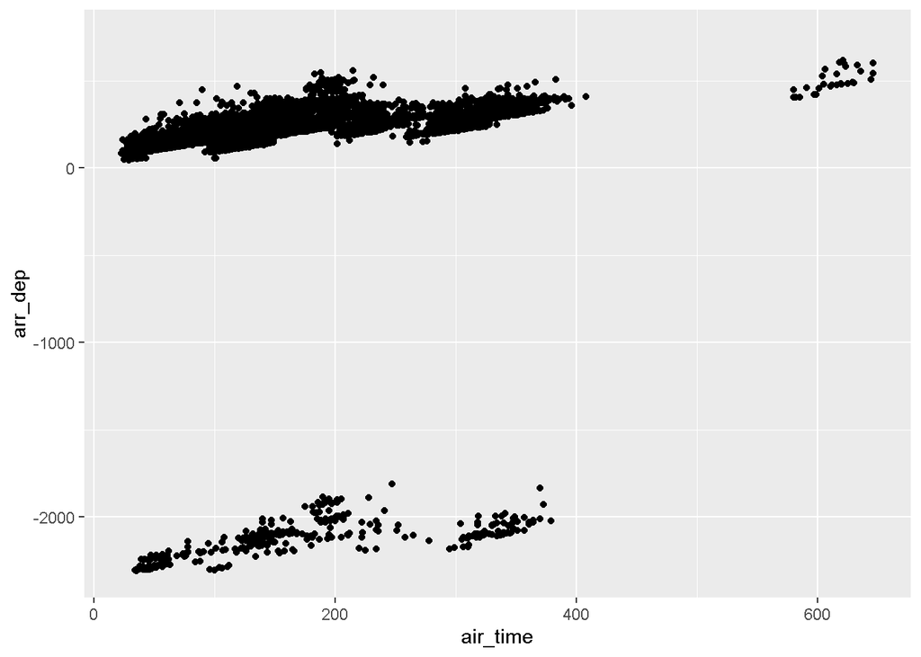

```r
flights %>%
  sample_n(10000) %>%
  select(air_time, arr_time, dep_time) %>%
  mutate(arr_dep = arr_time - dep_time) %>%
  mutate(equal = air_time == arr_dep) %>%
  ggplot(aes(air_time, arr_dep)) +
  geom_point()
```

3. Compare dep_time, sched_dep_time, and dep_delay. How would you expect those three numbers to be related?

```r
flights %>%
  select(dep_time, sched_dep_time, dep_delay) %>%
  head() %>%
  mytable()
```

| dep_time | sched_dep_time | dep_delay |
| --- | --- | --- |
| 517 | 515 | 2 |
| 533 | 529 | 4 |
| 542 | 540 | 2 |
| 544 | 545 | -1 |
| 554 | 600 | -6 |
| 554 | 558 | -4 |

4. Find the 10 most delayed flights using a ranking function. How do you want to handle ties? Carefully read the documentation for min_rank().

```r
flights %>%
  select(origin, carrier, dep_delay) %>%
  # arrange(desc(dep_delay)) %>%
  mutate(minrank = min_rank(desc(dep_delay)),
         rowrank = row_number(desc(dep_delay)),
         denserank = dense_rank(desc(dep_delay))) %>%
  arrange(desc(dep_delay)) %>%
  head() %>%
  mytable()
```

| origin | carrier | dep_delay | minrank | rowrank | denserank |
| --- | --- | --- | --- | --- | --- |
| JFK | HA | 1301 | 1 | 1 | 1 |
| JFK | MQ | 1137 | 2 | 2 | 2 |
| EWR | MQ | 1126 | 3 | 3 | 3 |
| JFK | AA | 1014 | 4 | 4 | 4 |
| JFK | MQ | 1005 | 5 | 5 | 5 |
| JFK | DL | 960 | 6 | 6 | 6 |

5. What does 1:3 + 1:10 return? Why?

```r
1:3 + 1:10
```

```
##  [1]  2  4  6  5  7  9  8 10 12 11
```

6. What trigonometric functions does R provide?

`sin()`, `cos`, `tan`

## 5.6 Grouped summaries with `summarise`

Useful summarise functions:

- `mean()`, `median()`, `sd()`, `IQR()`, `mad()`
- `min()`, `quantile(x, 0.5)`, `max()`
- `first()`, `nth(x,2)`, `last()`
- `n()`, `n_distinct()`, `sum(!is.na(x))`
- `count()`, `count(x, wt = y)`

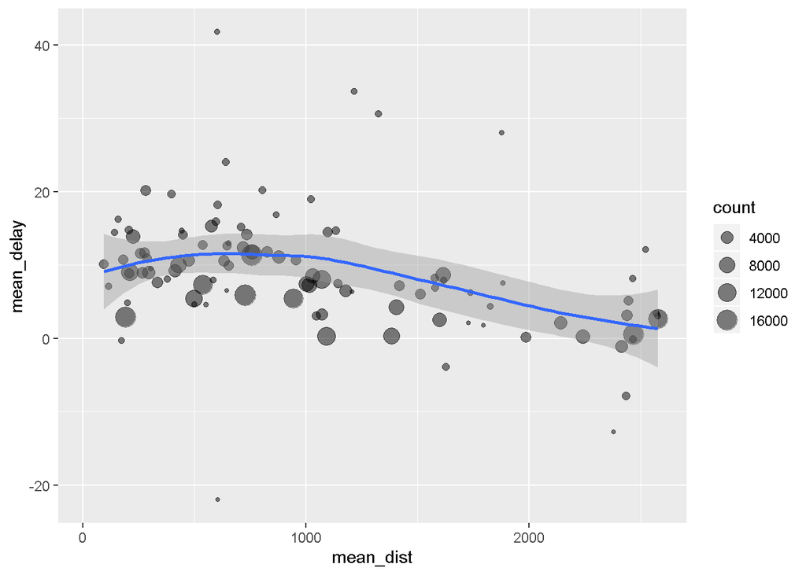

```r
flights %>%
  group_by(dest) %>%
  summarise(
    count = n(),
    mean_delay = mean(arr_delay, na.rm = TRUE),
    mean_dist = mean(distance, na.rm = TRUE)) %>%
  filter(mean_dist <3000) %>%
  ggplot(aes(mean_dist, mean_delay)) +
  geom_point(aes(size = count), alpha = 0.5) +
  geom_smooth()
```

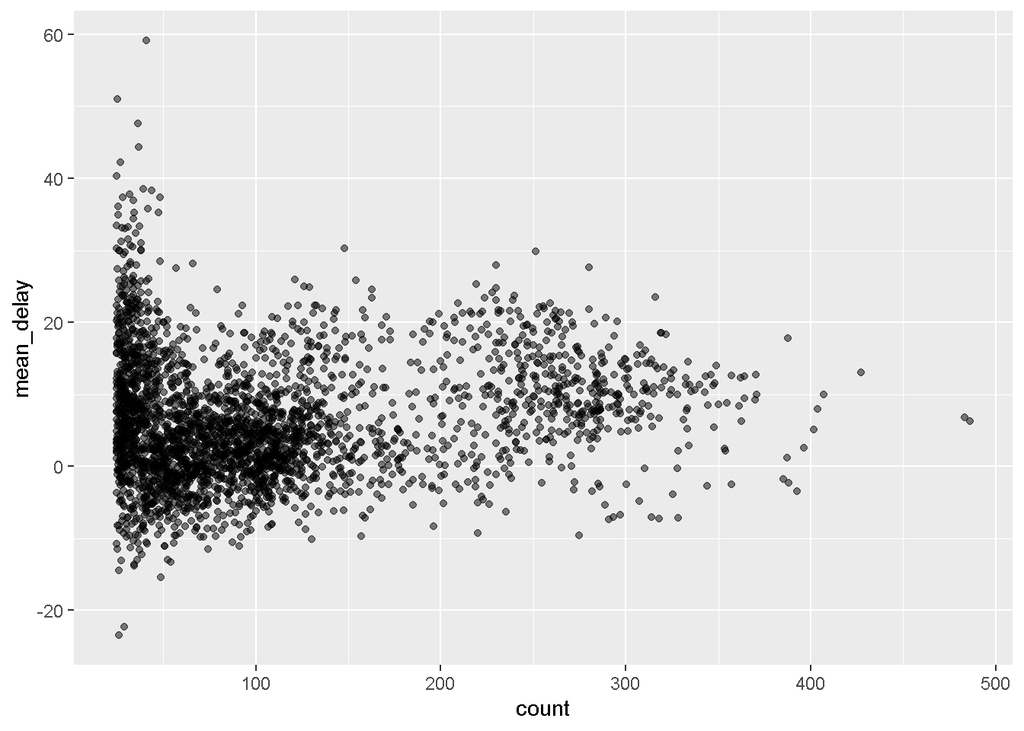

```r
flights %>%
  group_by(tailnum) %>%
  summarize(
    count = n(),
    mean_delay = mean(arr_delay, na.rm = TRUE)) %>%
  filter(between(count, 25, 500)) %>%
  ggplot(aes(count, mean_delay)) +
  geom_point(alpha = 0.5, position = "jitter")
```

```r
summary_flights <- flights %>%
  select(dest, arr_delay) %>%
  filter(!is.na(arr_delay)) %>%
  group_by(dest) %>%
  summarize(mean = mean(arr_delay),
            mean_pos = mean(arr_delay[arr_delay > 0]),
            median = median(arr_delay),
            sd = sd(arr_delay[arr_delay > 0]),
            iqr = IQR(arr_delay),
            mad = mad(arr_delay),
            min = min(arr_delay),
            quantile50 = quantile(arr_delay, 0.5),
            max = max(arr_delay),
            first = first(arr_delay),
            last = last(arr_delay))
summary_flights %>%
  head() %>%
  mytable()
```

| dest | mean | mean_pos | median | sd | iqr | mad | min | quantile50 | max | first | last |
| --- | --- | --- | --- | --- | --- | --- | --- | --- | --- | --- | --- |
| ABQ | 4.381890 | 41.93458 | -5.5 | 38.39130 | 46.75 | 33.3585 | -61 | -5.5 | 153 | -35 | -39 |
| ACK | 4.852273 | 28.59615 | -3.0 | 35.95237 | 23.00 | 16.3086 | -25 | -3.0 | 221 | -14 | -6 |
| ALB | 14.397129 | 52.06522 | -4.0 | 56.43039 | 45.00 | 22.9803 | -34 | -4.0 | 328 | -10 | -23 |
| ANC | -2.500000 | 12.40000 | 1.5 | 15.46932 | 20.75 | 12.6021 | -47 | 1.5 | 39 | 1 | -4 |
| ATL | 11.300113 | 37.79247 | -1.0 | 57.14725 | 28.00 | 19.2738 | -49 | -1.0 | 895 | -25 | 136 |
| AUS | 6.019909 | 40.63072 | -5.0 | 49.31995 | 34.00 | 23.7216 | -59 | -5.0 | 349 | 40 | -52 |

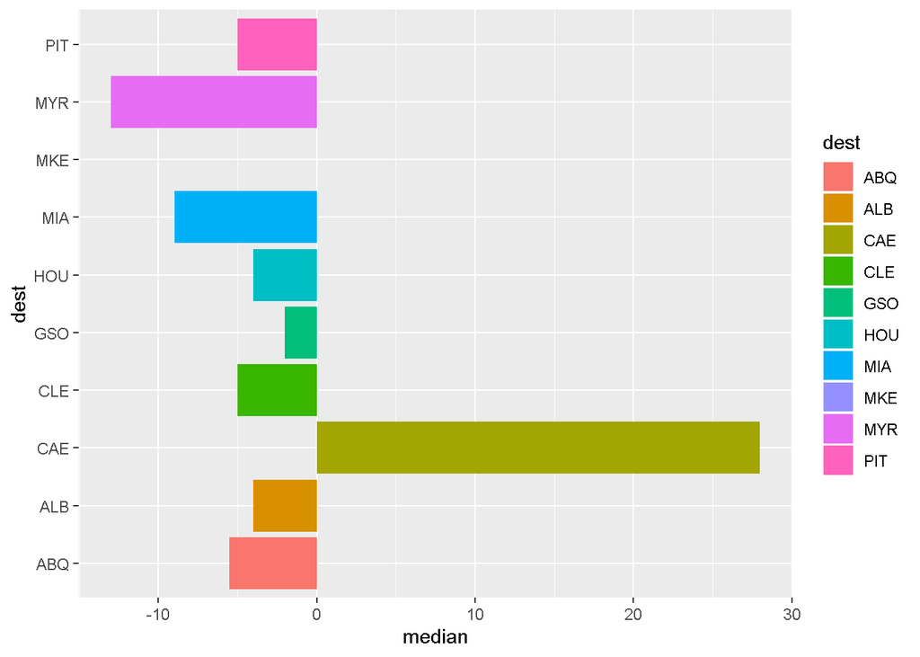

```r
summary_flights %>%
  sample_n(10) %>%
  ggplot(aes(x = dest, y = median)) +
  geom_bar(aes(fill = dest), stat = "identity") +
  coord_flip()
```

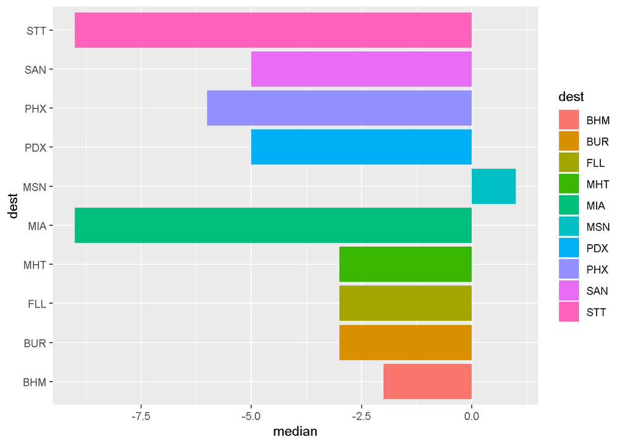

```r
summary_flights %>%
  sample_n(10) %>%
  ggplot(aes(x = dest, y = median)) +
  geom_col(aes(fill = dest)) +
  coord_flip()
```

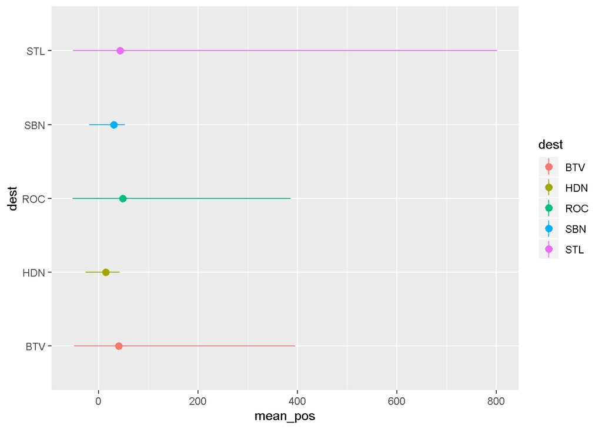

```r
summary_flights %>%
  sample_n(5) %>%
  ggplot(aes(x = dest, y = mean_pos, color = dest)) +
  geom_pointrange(aes(ymin = min, ymax = max)) +
  coord_flip()
```

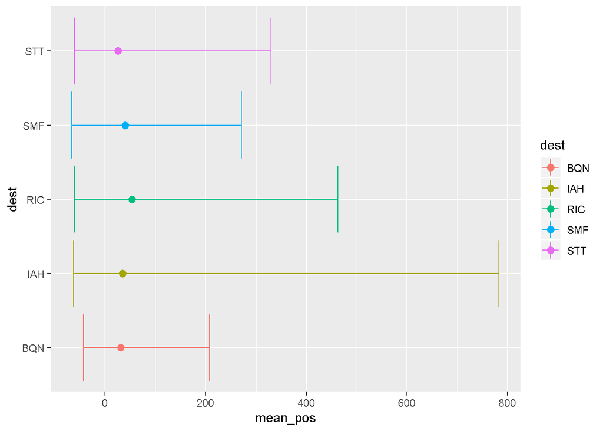

```r
summary_flights %>%
  sample_n(5) %>%
  ggplot(aes(x = dest, y = mean_pos, color = dest)) +
  geom_pointrange(aes(ymin = min, ymax = max)) +
  geom_errorbar(aes(ymin = min, ymax = max)) +
  coord_flip()
```

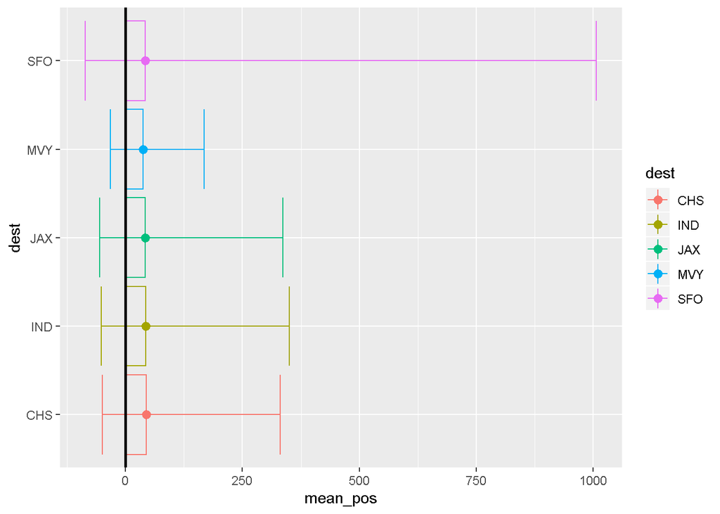

```r
summary_flights %>%
  sample_n(5) %>%
  ggplot(aes(x = dest, y = mean_pos)) +
  geom_bar(aes(color = dest), fill = NA, stat = "identity", show.legend = FALSE) +
  geom_pointrange(aes(ymin = min, ymax = max, color = dest)) +
  geom_errorbar(aes(ymin = min, ymax = max, color = dest)) +
  geom_hline(yintercept = 0, color = "black", size = 1) +
  coord_flip()
```

**Calculate proportions**

Where do people go?

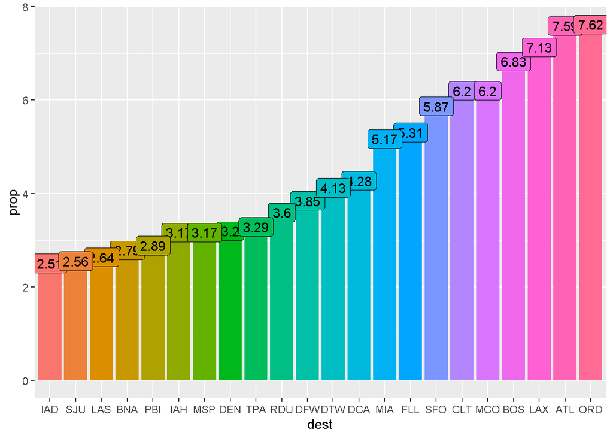

```r
flights %>%
  select(dest) %>%
  group_by(dest) %>%
  filter(n() > 5000) %>%
  ungroup() %>%
  count(dest, name = "total") %>%
  mutate(prop = round(total/sum(total)*100,2)) %>%
  mutate(dest = fct_reorder(dest, prop)) %>%
  ggplot(aes(dest, prop, fill = dest)) +
  geom_col(show.legend = FALSE) +
  geom_label(
    aes(label = prop, y = prop), show.legend = FALSE)
```

**Proportions for a dicotomous cathegory**

```r
flights %>%
  summarise(mean(arr_delay < 0, na.rm = TRUE))
```

```
## # A tibble: 1 x 1
##   `mean(arr_delay < 0, na.rm = TRUE)`
##                                 <dbl>
## 1                               0.577
```

```r
flights %>%
  mutate(
    arr_cat = case_when(
      arr_delay < 0 ~ "earlier",
      arr_delay == 0 ~ "sharp",
      arr_delay > 0 ~ "late",
      is.na(arr_delay) ~ "cancelled"
    )
  ) %>%
  count(arr_cat, name = "total") %>%
  mutate(prop = total / sum(total),
         total_count = sum(total))
```

```
## # A tibble: 4 x 4
##   arr_cat    total   prop total_count
##   <chr>      <int>  <dbl>       <int>
## 1 cancelled   9430 0.0280      336776
## 2 earlier   188933 0.561       336776
## 3 late      133004 0.395       336776
## 4 sharp       5409 0.0161      336776
```

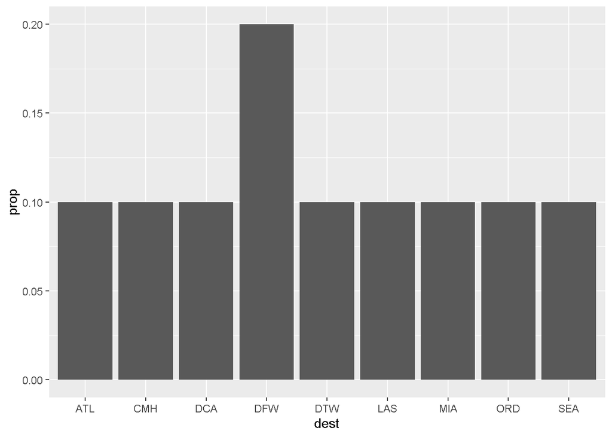

```r
flights %>%
  sample_n(10) %>%
  ggplot(aes(dest))+
  geom_bar(aes(y = ..prop.., group = 1))
```

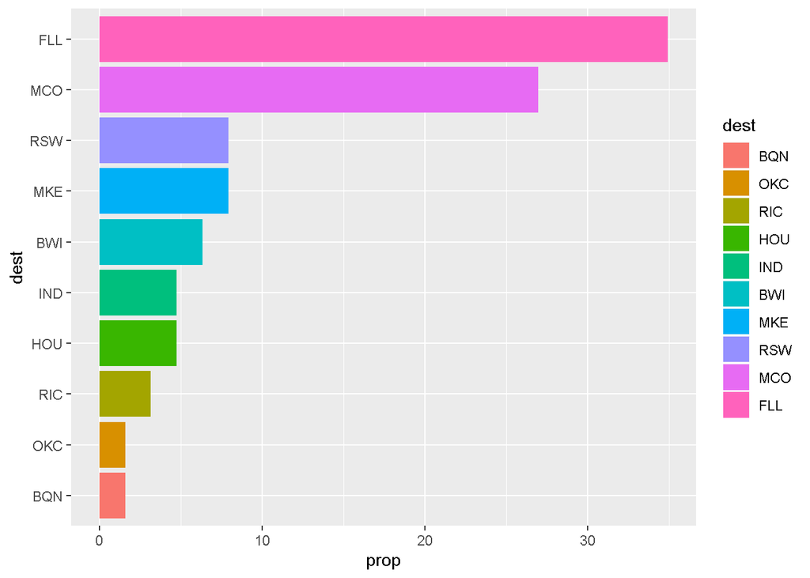

```r
flights %>%
  sample_n(500) %>%
  count(dest, name = "count") %>%
  sample_n(10) %>%
  mutate(prop = round(count/sum(count)*100,2),
         dest = fct_reorder(dest, prop)) %>%
  filter(prop > 1) %>%
  ggplot(aes(dest, prop)) +
  geom_col(aes(fill=dest)) +
  # geom_label(aes(label = prop, y = prop)) +
  coord_flip()
```

## Tips based on exercises

**How other functions change with grouping**

Summary functions `(mean())`, offset functions `(lead(), lag())`, ranking functions `(min_rank(), row_number())`, operate within each group when used with `group_by()` in `mutate()` or `filter()`. Arithmetic operators `(+, -)`, logical operators `(<, ==)`, modular arithmetic operators `(%%, %/%)`, logarithmic functions `(log)` are **not** affected by `group_by`.

What time of day should you fly if you want to avoid delays as much as possible?

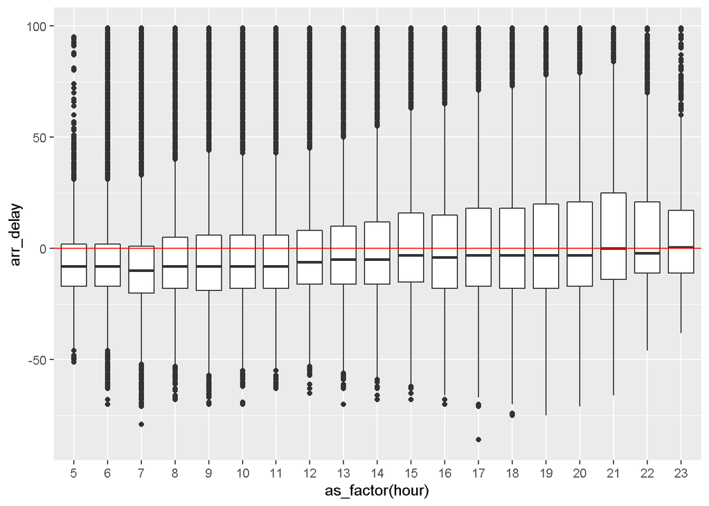

```r
flights %>%
  filter(arr_delay < 100) %>%
  ggplot(aes(as_factor(hour), arr_delay)) +
  geom_boxplot() +
  geom_hline(yintercept = 0, color = "red")
```

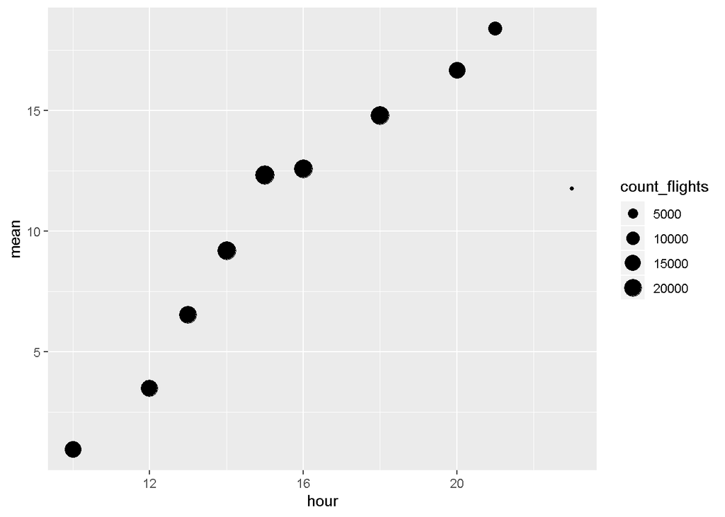

```r
flights %>%
  group_by(hour) %>%
  summarise(
    count_flights = n(),
    mean = mean(arr_delay, na.rm = TRUE),
    quant = quantile(arr_delay, 0.95, na.rm = TRUE)
  ) %>%
  ungroup() %>%
  filter(hour != 1) %>%
  sample_n(10) %>%
  ggplot(aes(hour, mean, size = count_flights)) +
  geom_point()
```

For each destination, compute the total minutes of delay. For each flight, compute the proportion of the total delay for its destination.

```r
flights %>%
  group_by(dest) %>%
  mutate(total_min_delay = sum(abs(arr_delay), na.rm = TRUE) + sum(abs(dep_delay), na.rm = TRUE),
         prop_delay = 100*(abs(arr_delay) + abs(dep_delay)) /total_min_delay
            ) %>%
  arrange(prop_delay) %>%
  ungroup() %>%
  arrange(dest) %>%
  select(dest, prop_delay, total_min_delay) %>%
  slice(1:10) %>%
  mytable()
```

| dest | prop_delay | total_min_delay |
| --- | --- | --- |
| ABQ | 0.0000000 | 12523 |
| ABQ | 0.0159706 | 12523 |
| ABQ | 0.0239559 | 12523 |
| ABQ | 0.0239559 | 12523 |
| ABQ | 0.0319412 | 12523 |
| ABQ | 0.0319412 | 12523 |
| ABQ | 0.0319412 | 12523 |
| ABQ | 0.0399265 | 12523 |
| ABQ | 0.0399265 | 12523 |
| ABQ | 0.0399265 | 12523 |

For each plane, count the number of flights before the first delay of greater than 1 hour

```r
flights %>%
  select(tailnum, year, month, day, dep_delay) %>%
  mutate(dep_delay_hr = dep_delay / 60,
         dep_delay_hr = ifelse(dep_delay_hr < 0, 0 , dep_delay_hr)) %>%
  arrange(tailnum, year, month, day) %>%
  group_by(tailnum) %>%
  mutate(less_1 = cumsum(dep_delay_hr),
         number = row_number()) %>%
  filter(less_1 < 1) %>%
  slice(last(number))  %>%
  head() %>%
  mytable()
```

| tailnum | year | month | day | dep_delay | dep_delay_hr | less_1 | number |
| --- | --- | --- | --- | --- | --- | --- | --- |
| N0EGMQ | 2013 | 1 | 9 | -3 | 0.0 | 0.9000000 | 15 |
| N10156 | 2013 | 1 | 10 | 48 | 0.8 | 0.8000000 | 2 |
| N102UW | 2013 | 5 | 9 | -7 | 0.0 | 0.9333333 | 11 |
| N103US | 2013 | 12 | 15 | -9 | 0.0 | 0.5666667 | 46 |
| N104UW | 2013 | 2 | 10 | -8 | 0.0 | 0.4833333 | 3 |
| N105UW | 2013 | 6 | 10 | -11 | 0.0 | 0.6000000 | 14 |